# Notebook

### Web Information Retrieval and Data Mining - Assignment 3

```
Student: KUBICA, MICHAŁ (1551019)
```

#### Answer 1.1, Baseline (4p)

- Dense network, at least 3 layers, shaped like a pyramid
  - Last layer: 10 nodes, sigmoid.
  - Loss: categorical cross-entropy. Metric: accuracy
- No preprocessing, regularization. Get at least 70% accuracy.
- Explain design decisions. Discuss performance.
  - Does it overfit (large/growing gap between loss and val_loss)?

[output not shown]

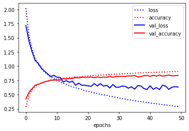

```
Model: "sequential_55"
_________________________________________________________________
Layer (type)                 Output Shape              Param #
=================================================================
reshape_8 (Reshape)          (None, 3072)              0
_________________________________________________________________
dense_255 (Dense)            (None, 1024)              3146752
_________________________________________________________________
dense_256 (Dense)            (None, 512)               524800
_________________________________________________________________
dense_257 (Dense)            (None, 256)               131328
_________________________________________________________________
dense_258 (Dense)            (None, 128)               32896
_________________________________________________________________
dense_259 (Dense)            (None, 64)                8256
_________________________________________________________________
dense_260 (Dense)            (None, 32)                2080
_________________________________________________________________
dense_261 (Dense)            (None, 10)                330
=================================================================
Total params: 3,846,442
Trainable params: 3,846,442
Non-trainable params: 0
_________________________________________________________________
None
def build_model_1_1():
    model = models.Sequential()
    model.add(layers.Reshape((3072,), input_shape=(32,32,3)))
    model.add(layers.Dense(1024, activation='relu'))
    model.add(layers.Dense(512, activation='relu'))
    model.add(layers.Dense(256, activation='relu'))
    model.add(layers.Dense(128, activation='relu'))
    model.add(layers.Dense(64, activation='relu'))
    model.add(layers.Dense(32, activation='relu'))
    model.add(layers.Dense(10, activation='softmax'))
    model.compile(optimizer=optimizers.RMSprop(learning_rate=0.000015, rho=0.9, momentum=0.9),
                  loss='categorical_crossentropy',
                  metrics=['accuracy'])
    return model
```

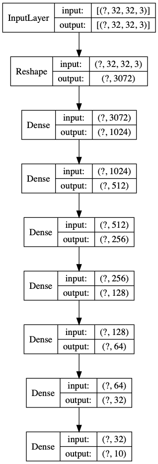

#### Answer 1.2, Preprocess (2p)

- Convert images to greyscale, other preprocessing optional.
  - Input shape should be (32,32,1)
- Explain design decisions. Is it better? Why (not)?
  - Color information is likely not so useful for classification. Greyscale makes the network smaller, less parameters to learn, less likely to overfit.

[output not shown]

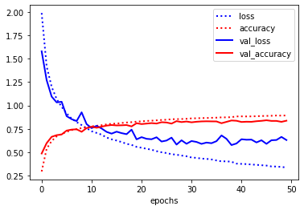

```
Model: "sequential_77"
_________________________________________________________________
Layer (type)                 Output Shape              Param #
=================================================================
reshape_30 (Reshape)         (None, 1024)              0
_________________________________________________________________
dense_407 (Dense)            (None, 512)               524800
_________________________________________________________________
dense_408 (Dense)            (None, 256)               131328
_________________________________________________________________
dense_409 (Dense)            (None, 128)               32896
_________________________________________________________________
dense_410 (Dense)            (None, 64)                8256
_________________________________________________________________
dense_411 (Dense)            (None, 32)                2080
_________________________________________________________________
dense_412 (Dense)            (None, 10)                330
=================================================================
Total params: 699,690
Trainable params: 699,690
Non-trainable params: 0
_________________________________________________________________
None
def build_model_1_2():
    model = models.Sequential()
    model.add(layers.Reshape((1024,), input_shape=(32,32,1)))
    model.add(layers.Dense(512, activation='relu'))
    model.add(layers.Dense(256, activation='relu'))
    model.add(layers.Dense(128, activation='relu'))
    model.add(layers.Dense(64, activation='relu'))
    model.add(layers.Dense(32, activation='relu'))
    model.add(layers.Dense(10, activation='softmax'))
    model.compile(optimizer=optimizers.RMSprop(learning_rate=0.00005, rho=0.9, momentum=0.9),
                  loss='categorical_crossentropy',
                  metrics=['accuracy'])
    return model
```

#### Answer 1.3, Tune (4p)

- Regularize the model. What works best?
  - Should consider batch normalization, dropout, l1/l2 regularization (or Nesterov)
- Tune other hyperparameters (e.g. learning rate, batch size,...) as you see fit.
  - At least consider tuning learning rate, ideally also momentum, decay, other optimizers
- Explain your findings and final design decisions. Discuss the results.
  - Should be better, at least it shouldn't overfit

[output not shown]

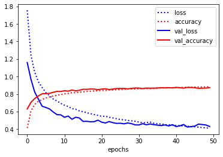

```
def build_model_1_3():
    model = models.Sequential()
    model.add(layers.Reshape((1024,), input_shape=(32,32,1)))
    model.add(layers.BatchNormalization())
    model.add(layers.Dense(512, activation='relu'))
    model.add(layers.Dropout(0.1))
    model.add(layers.BatchNormalization())
    model.add(layers.Dense(256, activation='relu'))
    model.add(layers.Dropout(0.1))
    model.add(layers.BatchNormalization())
    model.add(layers.Dense(128, activation='relu'))
    model.add(layers.Dropout(0.1))
    model.add(layers.BatchNormalization())
    model.add(layers.Dense(64, activation='relu'))
    model.add(layers.Dropout(0.1))
    model.add(layers.BatchNormalization())
    model.add(layers.Dense(32, activation='sigmoid'))
    model.add(layers.Dropout(0.1))
    model.add(layers.BatchNormalization())
    model.add(layers.Dense(12, activation='sigmoid'))
    model.add(layers.Dropout(0.1))
    model.add(layers.BatchNormalization())
    model.add(layers.Dense(10, activation='softmax'))
    model.compile(optimizer=optimizers.RMSprop(learning_rate=0.0001, momentum=0.9),
                  loss='categorical_crossentropy',
                  metrics=['accuracy'])
    return model
```

#### Answer 2.1, ConvNet (7p)

- Build a sequential ConvNet, get at least 90% accuracy.
  - Conv2D layers, input shape (32,32,1)
  - Consider using blocks of Conv2D layers with maxpooling in between
  - Use zero-padding in Conv2D layers because the images are small
  - At least one dense hidden layer and dense output layer (sigmoid)
  - Consider adding batch normalization, dropout
  - Consider small dropout rates in beginning, larger dropout rates later in network
  - Consider other optimizers and tuning learning rate, momentum,...
- Explain what you did and why (800 chars). Is it working well?
  - Should be quite elaborate and sensible

[output not shown]

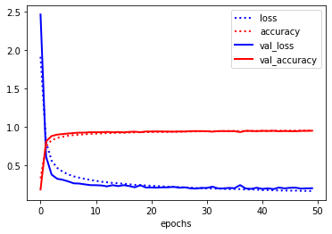

```
Model: "sequential_106"
_________________________________________________________________
Layer (type)                 Output Shape              Param #
=================================================================
conv2d_132 (Conv2D)          (None, 30, 30, 16)        160
_________________________________________________________________
batch_normalization_143 (Bat (None, 30, 30, 16)        64
_________________________________________________________________
leaky_re_lu_132 (LeakyReLU)  (None, 30, 30, 16)        0
_________________________________________________________________
conv2d_133 (Conv2D)          (None, 30, 30, 16)        2320
_________________________________________________________________
leaky_re_lu_133 (LeakyReLU)  (None, 30, 30, 16)        0
_________________________________________________________________
max_pooling2d_66 (MaxPooling (None, 15, 15, 16)        0
_________________________________________________________________
dropout_193 (Dropout)        (None, 15, 15, 16)        0
_________________________________________________________________
conv2d_134 (Conv2D)          (None, 15, 15, 32)        4640
_________________________________________________________________
batch_normalization_144 (Bat (None, 15, 15, 32)        128
_________________________________________________________________
leaky_re_lu_134 (LeakyReLU)  (None, 15, 15, 32)        0
_________________________________________________________________
conv2d_135 (Conv2D)          (None, 15, 15, 32)        9248
_________________________________________________________________
leaky_re_lu_135 (LeakyReLU)  (None, 15, 15, 32)        0
_________________________________________________________________
max_pooling2d_67 (MaxPooling (None, 7, 7, 32)          0
_________________________________________________________________
dropout_194 (Dropout)        (None, 7, 7, 32)          0
_________________________________________________________________
conv2d_136 (Conv2D)          (None, 7, 7, 64)          18496
_________________________________________________________________
batch_normalization_145 (Bat (None, 7, 7, 64)          256
_________________________________________________________________
leaky_re_lu_136 (LeakyReLU)  (None, 7, 7, 64)          0
_________________________________________________________________
conv2d_137 (Conv2D)          (None, 7, 7, 64)          36928
_________________________________________________________________
```

[output cut: 67 more lines]

```

    model.add(layers.Flatten())
    model.add(layers.Dense(512, activation='sigmoid'))
    model.add(layers.Dropout(0.5))
    model.add(layers.Dense(10, activation='softmax'))

    model.compile(optimizer=optimizers.RMSprop(learning_rate=0.00005, momentum=0.9),
                  loss='categorical_crossentropy',
                  metrics=['accuracy'])

    # model.compile(optimizer=optimizers.Adam(learning_rate=0.001),
    #           loss='categorical_crossentropy',
    #           metrics=['accuracy'])

    return model
```

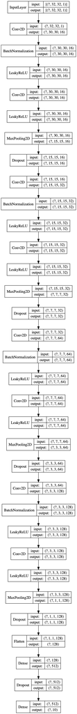

#### Answer 2.2, Data Augmentation (3p)

[output not shown]

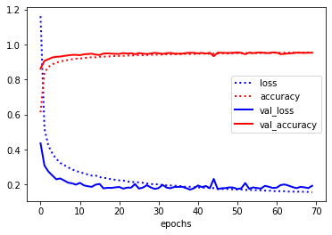

```
datagen = ImageDataGenerator(featurewise_center=False,
                             samplewise_center=False,
                             featurewise_std_normalization=False,
                             samplewise_std_normalization=False,
                             zca_whitening=False,
                             zca_epsilon=1e-06,
                             rotation_range=20,
                             width_shift_range=0.0,
                             height_shift_range=0.0,
                             brightness_range=None,
                             shear_range=0.0,
                             zoom_range=0.0,
                             channel_shift_range=0.0,
                             fill_mode='nearest',
                             cval=0.0,
                             horizontal_flip=False,
                             vertical_flip=False,
                             rescale=None,
                             preprocessing_function=None,
                             data_format='channels_last',
                             validation_split=0.0,
                             dtype='float32')
```

#### Answer 3.1, Misclassifications (2p)

[output not shown]

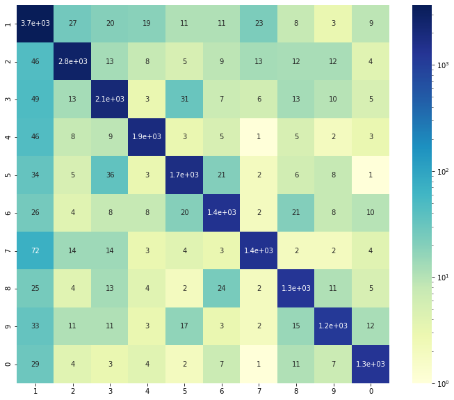

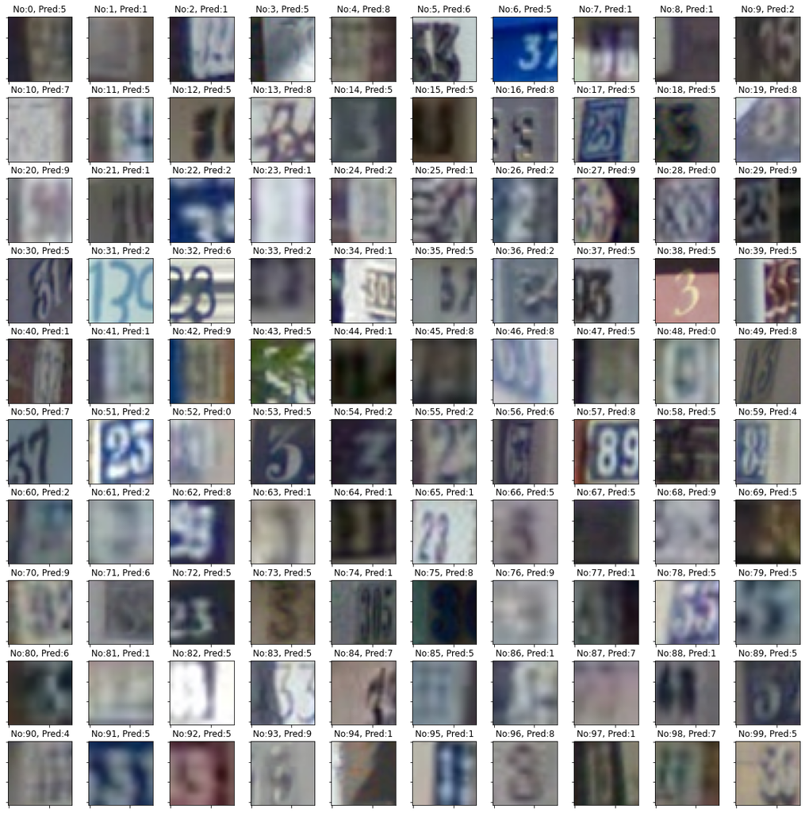

#### Answer 3.2, Activations (4p)

- Retrieve and visualize the activations for one example
- For every filter for different convolutional layers (at different depths in the network).
- Give an explanation. Is your model indeed learning something useful?
  - Should detect edges etc in first layers, higher-order object (e.g. interesting regions) in deeper layers.

[output not shown]

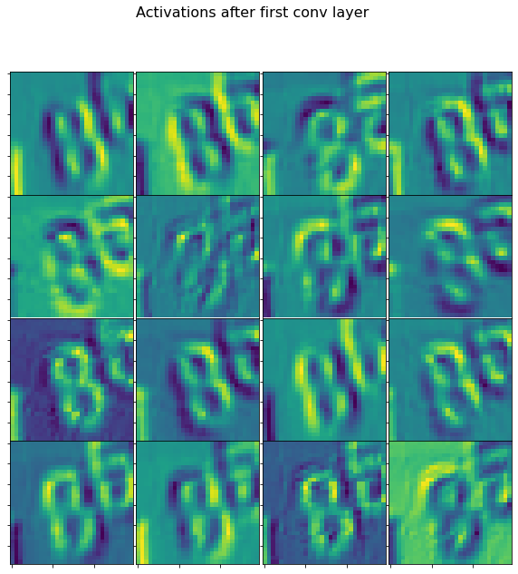

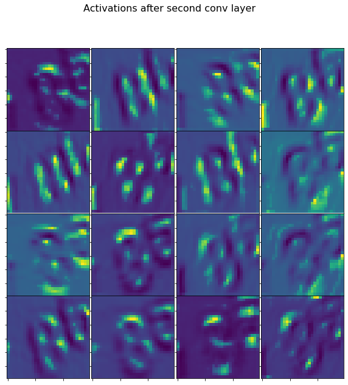

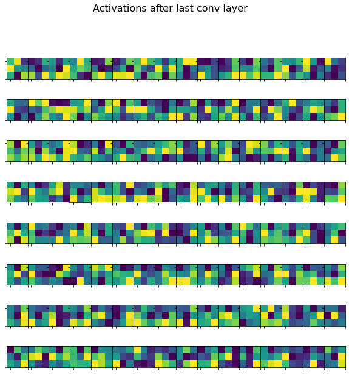

#### Answer 3.3, Class activation map (4p)

- Show a class activation map for your last convolutional layer
- Superimpose the activation map over the image, or plot side by side
  - Should make sense, detect interesting regions to classify the number

```
def plot_3_3():
  k=0
  model = load_model_from_file(base_dir, "model_2_2")
  last_conv_layer = model.get_layer('conv2d_31')
  img = rgb2gray(X_test)[k]
  #img = tf.keras.preprocessing.image.img_to_array(img)
  grad_model = tf.keras.models.Model([model.inputs], [model.get_layer('conv2d_31').output, model.output])

  with tf.GradientTape() as tape:
      conv_outputs, predictions = grad_model(np.array([img]))
      loss = predictions[:, np.argmax(y_test[k])]

  output = conv_outputs[0]
  grads = tape.gradient(loss, conv_outputs)[0]

  gate_f = tf.cast(output > 0, 'float32')
  gate_r = tf.cast(grads > 0, 'float32')
  guided_grads = tf.cast(output > 0, 'float32') * tf.cast(grads > 0, 'float32') * grads
  weights = tf.reduce_mean(guided_grads, axis=(0, 1))

  #weights = tf.reduce_mean(grads, axis=(0, 1))

  cam = np.ones(output.shape[0: 2], dtype = np.float32)
  for i, w in enumerate(weights):
      cam += w * output[:, :, i]
  o = cam.numpy()
  cam = cv2.resize(cam.numpy(), (32, 32))
  cam = np.maximum(cam, 0)

  heatmap = (cam - cam.min()) / (cam.max() - cam.min())
  cam = cv2.applyColorMap(np.uint8(255*heatmap), cv2.COLORMAP_JET)
  output_image = cv2.addWeighted(cv2.cvtColor(img.astype('uint8'), cv2.COLOR_RGB2BGR), 0.5, cam, 1, 0)


  fig, (ax1, ax2, ax3) = plt.subplots(1,3, figsize = (10,10))

  ax1.imshow(X_test[k])
  ax2.imshow(output_image, alpha=0.6)

  extent = 0,32,0,32
  im1 = ax3.imshow(X_test[k],
                  extent=extent)

  im2 = ax3.imshow(output_image, alpha=.3,
                  extent=extent)
```

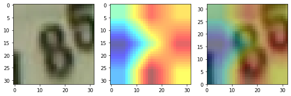

#### Answer 4.1, Fast feature extraction (5p)

- Import the VGG16 model, pretrained on ImageNet
- Freeze convolutional base, adds a dense layer
- Consider unfreezing the last few convolutional layers and evaluate whether that works better
  - Check if they do. It is very likely to help.
- Discuss the observed performance
  - Should get around 80% accuracy

[output not shown]

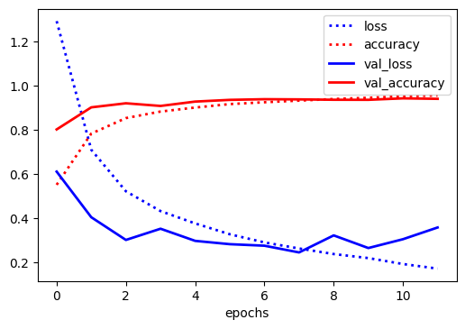

```
Model: "sequential_21"
_________________________________________________________________
Layer (type)                 Output Shape              Param #
=================================================================
vgg16 (Model)                (None, 1, 1, 512)         14714688
_________________________________________________________________
flatten_16 (Flatten)         (None, 512)               0
_________________________________________________________________
dense_88 (Dense)             (None, 256)               131328
_________________________________________________________________
dense_89 (Dense)             (None, 128)               32896
_________________________________________________________________
dense_90 (Dense)             (None, 64)                8256
_________________________________________________________________
dense_91 (Dense)             (None, 32)                2080
_________________________________________________________________
dropout_38 (Dropout)         (None, 32)                0
_________________________________________________________________
dense_92 (Dense)             (None, 10)                330
=================================================================
Total params: 14,889,578
Trainable params: 14,629,418
Non-trainable params: 260,160
_________________________________________________________________
None
def build_model_4_1():

  vgg_conv = VGG16(weights='imagenet', include_top=False, input_shape=(32, 32, 3))
  for layer in vgg_conv.layers[0:6]:
      layer.trainable = False


  # Create the model
  model = models.Sequential()
  # Add the vgg convolutional base model
  model.add(vgg_conv)
  # Add new layers
  model.add(layers.Flatten())
  model.add(layers.Dense(256, activation='relu'))
  model.add(layers.Dense(128, activation='relu'))
  model.add(layers.Dense(64, activation='relu'))
  model.add(layers.Dense(32, activation='relu'))
  model.add(layers.Dropout(0.5))
  model.add(layers.Dense(10, activation='softmax'))

  # Show a summary of the model. Check the number of trainable parameters
  model.summary()
  model.compile(optimizer=optimizers.RMSprop(learning_rate=0.00001, rho=0.9, momentum=0.9),
          loss='categorical_crossentropy',
          metrics=['accuracy'])


  return model
```

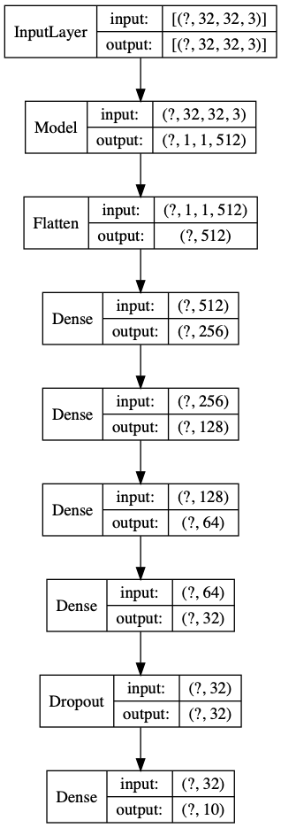

#### Answer 4.2, Embeddings (5p)

```
Not done  (length: 10)

None
def store_embeddings():
  """ Stores all necessary embeddings to file
  """
  pass

def evaluation_4_2(X_train, y_train, X_test, y_test):
  """ Runs 'evaluate_pipeline' with embedded versions of the input data
  and returns the accuracy.
  """
  pass
```

```
Running time: 82.73 seconds
Last modified: May 26, 2020
scikit-learn version: 0.23.1
```